# SMART Indicator Report: Annual Heatwave Intensity

## Indicator name

Annual Heatwave Intensity

Includes variable(s): cumulative intensity-BottomDetrended, cumulative intensity-SurfaceDetrended, duration-BottomDetrended, duration-SurfaceDetrended, maximum intensity-BottomDetrended, maximum intensity-SurfaceDetrended

## Indicator visualization

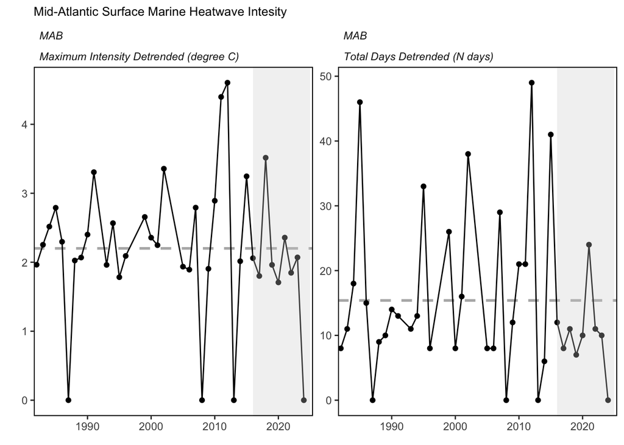

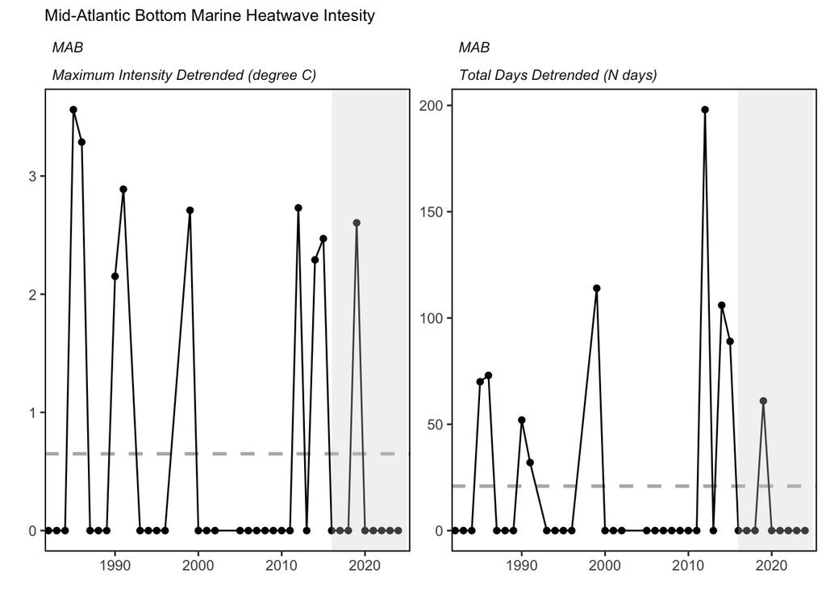

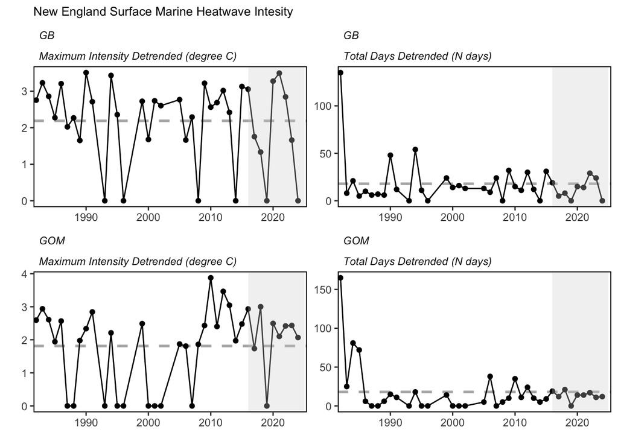

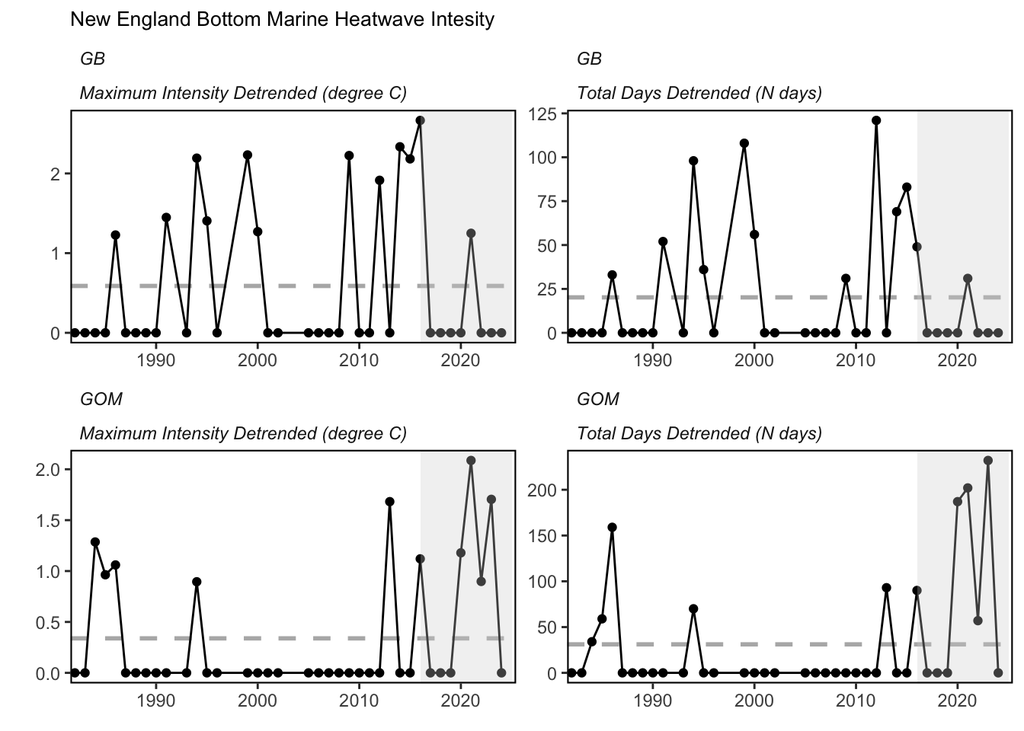

## Indicator documentation

### Are indicators available for others to use (data downloadable)?

```
## Yes
```

#### Where can indicators be found?

```
## Data: https://noaa-edab.github.io/ecodata/index.html
## Description:  https://noaa-edab.github.io/catalog/heatwave.html
## Technical documentation:  https://noaa-edab.github.io/tech-doc/heatwave.html
```

#### Who is the contact?

Vincent Saba (vincent.saba@noaa.gov)

### Gather indicator statistics

#### Units

| Indicator | Units |
| --- | --- |
| cumulative intensity-BottomDetrended | degrees C |
| cumulative intensity-SurfaceDetrended | degrees C |
| duration-BottomDetrended | N days |
| duration-SurfaceDetrended | N days |
| maximum intensity-BottomDetrended | degrees C |
| maximum intensity-SurfaceDetrended | degrees C |

#### Length of time series, start and end date, periodicity

General overview: Annual

Indicator specifics:

| Indicator | EPU | StartYear | EndYear | NumYears | MissingYears |
| --- | --- | --- | --- | --- | --- |
| cumulative intensity-BottomDetrended | GB | 1982 | 2024 | 38 | 5 |
| cumulative intensity-BottomDetrended | GOM | 1982 | 2024 | 38 | 5 |
| cumulative intensity-BottomDetrended | MAB | 1982 | 2024 | 38 | 5 |
| cumulative intensity-SurfaceDetrended | GB | 1982 | 2024 | 38 | 5 |
| cumulative intensity-SurfaceDetrended | GOM | 1982 | 2024 | 38 | 5 |
| cumulative intensity-SurfaceDetrended | MAB | 1982 | 2024 | 38 | 5 |
| duration-BottomDetrended | GB | 1982 | 2024 | 38 | 5 |
| duration-BottomDetrended | GOM | 1982 | 2024 | 38 | 5 |
| duration-BottomDetrended | MAB | 1982 | 2024 | 38 | 5 |
| duration-SurfaceDetrended | GB | 1982 | 2024 | 38 | 5 |
| duration-SurfaceDetrended | GOM | 1982 | 2024 | 38 | 5 |
| duration-SurfaceDetrended | MAB | 1982 | 2024 | 38 | 5 |
| maximum intensity-BottomDetrended | GB | 1982 | 2024 | 38 | 5 |
| maximum intensity-BottomDetrended | GOM | 1982 | 2024 | 38 | 5 |
| maximum intensity-BottomDetrended | MAB | 1982 | 2024 | 38 | 5 |
| maximum intensity-SurfaceDetrended | GB | 1982 | 2024 | 38 | 5 |
| maximum intensity-SurfaceDetrended | GOM | 1982 | 2024 | 38 | 5 |
| maximum intensity-SurfaceDetrended | MAB | 1982 | 2024 | 38 | 5 |

#### Spatial location, scale and extent

General overview: EPU

Indicator specifics:

| Indicator | EPU |
| --- | --- |
| cumulative intensity-BottomDetrended | GB |
| cumulative intensity-BottomDetrended | GOM |
| cumulative intensity-BottomDetrended | MAB |
| cumulative intensity-SurfaceDetrended | GB |
| cumulative intensity-SurfaceDetrended | GOM |
| cumulative intensity-SurfaceDetrended | MAB |
| duration-BottomDetrended | GB |
| duration-BottomDetrended | GOM |
| duration-BottomDetrended | MAB |
| duration-SurfaceDetrended | GB |
| duration-SurfaceDetrended | GOM |
| duration-SurfaceDetrended | MAB |
| maximum intensity-BottomDetrended | GB |
| maximum intensity-BottomDetrended | GOM |
| maximum intensity-BottomDetrended | MAB |
| maximum intensity-SurfaceDetrended | GB |
| maximum intensity-SurfaceDetrended | GOM |
| maximum intensity-SurfaceDetrended | MAB |

### Are methods clearly documented to obtain source data and calculate indicators?

```
## Yes
```

## Indicator analysis/testing or history of use

### What decision or advice processes are the indicators currently used in?

Marine heatwaves (MHWs) measure not just temperature, but how long the ecosystem is subjected to the high temperature. They are driven by both atmospheric and oceanographic factors and can have dramatic impacts on marine ecosystems. Marine heatwaves are measured in terms of intensity (water temperature) and duration (the cumulative number of degree days) using measurements of sea surface temperature (surface MHWs) or models of bottom temperature (bottom MHWs). Recent research ([99] and [100]) have modified the original MHW methodology, [101]. The MHW indices for both surface and bottom use temperature time-series data that are detrended and the entire time-series are used as the climatology (e.g. 1982-2024 in this SOE). Surface MHW events are based on the criteria of a warming event that lasts for five or more days with sea surface temperatures above the 90th percentile of the historical daily climatology (1982-2024). Bottom MHW events are based on the criteria of a warming event that lasts for thirty or more days with bottom temperatures above the 90th percentile of the historical daily climatology (1982-2024). The longer time period criterion for bottom temperature is due to the longer persistence time of ocean bottom temperature anomalies in the U.S. northeast shelf ([82]). The new MHW indices can now discern extreme events that truly are “extreme” rather than occupying most of the year. Because this approach moves from a fixed baseline to a shifting baseline by detrending ocean temperature data and using the entire time-series as a climatology, the global warming signal is removed and thus we are left with extremes in the variability of ocean temperature. To assess total heat stress on marine organisms, one can combine long-term ocean warming and MHWs. Therefore, the 2025 SOE also reports on long-term SST and bottom temperature time-series that clearly show the decadal ocean warming trend.

### What implications of the indicators are currently listed?

Implications of MHWs on living marine resources in the U.S.NES are currently being investigated. The 2012 surface MHW events in the Gulf of Maine did have impacts on the lobster fishery in the summer and fall of 2012.

## Comments

### Additional potential links to management in addition to uses listed above

### What additional work would be needed for the Council to use the indicator?

### What issues are caused if there is a gap or delay in data underlying the indicator